# Analytics Edge: Unit 8 - Google Adwords

Sulman Khan

October 26, 2018

## Optimizing Online Advertising

### Google Inc.

- Provides products and services related to the Internet
  - Mission: “… to organize the world’s information and make it universally accessible and useful.”
- Most widely known for its search engine
  - User enters a query, Google returns links to websites that best fit query

### History of Google

- 1996 - Sergei Brin and Larry Page, graduate students at Stanford, working on a research project
  - How to measure importance of any webpage using links on the internet
- 1998 - Incorporated Google as a company and received first funding; database of 60 million webpages
- 2005 - Initial Public Offering
- 2007 - Google acquires YouTube and other companies
- 2013 - **More than 1 billion unique monthly visitors**

### Google’s Business Model

- Google search engine is free to use, so how does Google make money?
- Answer: **online advertising**

### Google Advertising - AdWords

- Why do companies advertise on Google?
  - Google receives heavy traffic
  - Search pages are formatted in a very clean way
  - Companies can choose which type of queries their adds will be displayed for; better targeting
- 97% of Google’s revenues come from AdWords

### How does Advertising on Google work?

- Advertisers place bids for different queries in an auction
- Based on bids and *quality save* (fit of advertiser and ad to the queries), Google decides price-per-click of each advertisers and each query
- Google then decides how often to display each ad for each query

### Price-per-click (PPC)

- For each query, Google decides each advertiser’s **price-per-click (PPC)**
  - How much advertiser pays Google when user clicks ad for that query
- Each advertiser also species a **budget**
  - Each time user clicks on advertiser’s ad, budget is depleted by PPC amount

### Example of price-per-click

[figure not shown]

### Click-through Rate (CTR)

- Advertiser only pays Google if the user *clicks* on the ad
- The probability that a user clicks on an advertiser’s ad is the **click-through rate (CTR)**
  - Can also think of as “clicks per user”

### Example of click-through rate

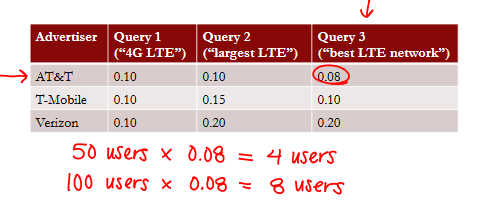

### Average Price Per Display

- Average amount that an advertiser pays each time its ad is shown is **PPC x CTR**

### How average per display works

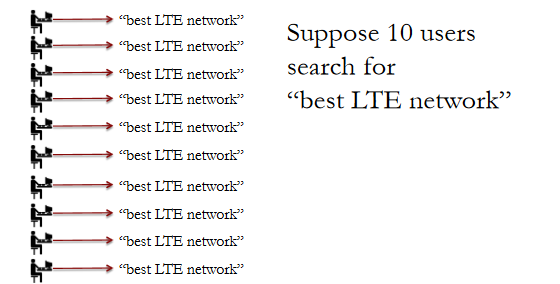

[figure not shown]

[figure not shown]

[figure not shown]

[figure not shown]

[figure not shown]

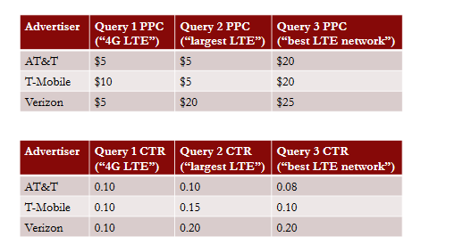

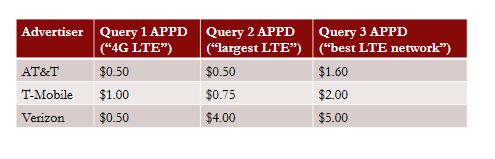

### Query estimates

- Google does not control how many times a query will be requested - driven by users!
- For each query, Google has estimate of number of times query will be requested over a given day

### Google’s problem

- **How many times to display each ad for each query to maximize revenue**
- Objective
  - Maximize revenue
- Decision
  - For each advertiser and query, number of times ad will be displayed for that query
- Constraints
  - Average amount paid by each advertiser cannot exceed budget
  - Total ads for given query cannot exceed estimated number of requests for that query

#### Problem data

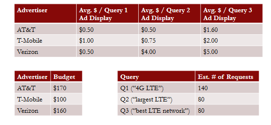

#### Modeling the problem

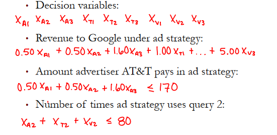

#### Slates/positions

- Search result page has space for more than one ad
- **Slate**: combination of ads
- Many possible slates: which ones to display?

#### Personalization

- In addition to the query, Google can use other information to decide which ad to display:
  - IP address/geographic location
  - Previous Google searches/browser activity on Google
- How do we account for this?

### AdWords at Google’s scale?

- In reality, problem is much larger
  - Hundreds to thousands of bidders, over $40 billion
  - Gains from optimization at this scale become enormous